# The Future of Original Content Programming

David Aimé Greven, Fynn Mehrens

11-1-2021

## Introduction

As the demand for content from various streaming services has grown over the years, companies have started to invest more resources into original content. We want to statistically check whether this strategy of original content instead of licensed content is promising or not.

To do this analysis, we are using scraped data from various Wikipedia pages. For this purpose, we have been using an external web scraper that scrapes all the **<table>** elements from the web page and converts them into a CSV format.

The **web scraping tool** can be found here:

- [Wiki Table to CSV online converter](https://wikitable2csv.ggor.de/)

For the **Netflix** sub dataset these web pages have been scraped:

- [List of Netflix Original Programming](https://en.wikipedia.org/wiki/List_of_Netflix_original_programming)
- [List of ended Netflix Original Programming](https://en.wikipedia.org/wiki/List_of_ended_Netflix_original_programming)
- [Lists of Netflix Original Films](https://en.wikipedia.org/wiki/Lists_of_Netflix_original_films)
- List of Netflix Original Films 2015
- List of Netflix Original Films 2018
- List of Netflix Original Films 2019
- List of Netflix Original Films 2020
- List of Netflix Original Films 2021
- [List of Netflix Original Stand-up Comedy](https://en.wikipedia.org/wiki/List_of_Netflix_original_stand-up_comedy_specials)
- [List of Netflix exclusive International Distribution Programming](https://en.wikipedia.org/wiki/List_of_Netflix_exclusive_international_distribution_programming)

For the **Amazon Prime Video** sub dataset these web pages have been scraped:

- [List of Amazon Original Programming](https://en.wikipedia.org/wiki/List_of_Amazon_original_programming)

For the **Hulu** sub dataset these web pages have been scraped:

- [List of Hulu Original Programming](https://en.wikipedia.org/wiki/List_of_Hulu_original_programming)

For the **Disney+** sub dataset these web pages have been scraped:

- [List of Disney+ Original Programming](https://en.wikipedia.org/wiki/List_of_Disney%2B_original_programming)
- [List of Disney+ Original Films](https://en.wikipedia.org/wiki/List_of_Disney%2B_original_films)

For the **Apple TV+** sub dataset these web pages have been scraped:

- [List of Apple TV+ Original Programming](https://en.wikipedia.org/wiki/List_of_Apple_TV%2B_original_programming)

## Disclaimer

If you run into any problems (can be recognized by missing Premiere values on the first page of the data frame called “netflix”), please make sure to contact us because there are various options for Unix-based operating systems, and we did not want to include them all for the case that they might conflict with each other.

## Installing required libraries

The first code chunk makes sure that all the required libraries are installed. The “**forcats**” library is included with the “**tidyverse**” but does not open all its functionality to the developer, so it needed to be explicitly required as well. To ensure correct parsing of the dates during the original content transmutation, the locale is set to an English one.

## Dataset Import

The upcoming chapter deals with the import of the scraped and downloaded CSVs into tibbles. Due to the enormous amount and inconsistencies of the CSV files, the importing process was very tedious and every single CSV file needed to be inspected and merged manually. This is performed for all of the streaming services.

### Custom functions for Import Phase

To exclude specific rows that do not match one of the specified statuses formats or origins, the only_keep() function was written to ease parsing the factors after matching parts of the previous entry to unify the column’s content.

```r
only_keep <- function(row, regex, factor) {
  return(parse_factor(str_match(row, regex)[,2], levels = factor))
}

bind_originals <- function(originals, count) {
  name <- deparse(substitute(originals))

  for(temp in map(sprintf(str_replace_all(paste(name, "_%s"), " ", ""), seq(3:count)), ~get(.))) {
    originals %<>% rbind(temp)
  }

  return(originals)
}

status_regex <- "(Renewed|Pending|Miniseries|Awaiting release|Event|Development|Ended|Film|Special|Distribution)"

format_regex <- "(Series|Miniseries|Film|Special)"

origin_regex <- "(Continuation|Distribution|Original)"

statuses <- c("Renewed", "Pending", "Miniseries", "Awaiting release", "Event", "Development", "Ended", "Film", "Special", "Distribution")

formats <- c("Series", "Miniseries", "Film", "Special")

origins <- c("Continuation", "Distribution", "Original")

services <- c("Netflix", "Amazon Prime Video", "Hulu", "Disney+", "Apple TV+")

ages <- c("0+", "6+", "7+", "12+", "13+", "16+", "18+", "all", "unknown")
```

## Import Netflix

To import all the required data, all 115 CSV files need to be imported, and in some cases, values have to be added, e.g., because the entry was found in a table for specific genres, but the genre was not further specified in the actual cells of the rows.

```r
netflix_originals_1 <- read_csv("../datasets/netflix/shows/table-1.csv") %>%
  transmute(Title = Title,
            Genre = paste(Genre, "Drama"),
            Premiere = Premiere,
            Seasons = Seasons,
            Runtime = Runtime,
            Language = NA,
            Status = Status,
            Format = "Series",
            Origin = "Original",
            Network = NA,
            Region = NA)
```

After importing the data into 115 individual data frames, the tables now need to be merged horizontally using the **rbind()** function. This function requires the tables to have NA values for the columns that were not initially specified in the CSV files; thus, the large number of NA transmutes.

```r
netflix_originals <- rbind(netflix_originals_1, netflix_originals_2)
netflix_originals <- bind_originals(netflix_originals, 115)

(netflix_originals %<>%
  transmute(Title = Title,
            Genre = Genre,
            Premiere = Premiere,
            Seasons = Seasons,
            Runtime = Runtime,
            Language = Language,
            Status = only_keep(Status, status_regex, statuses),
            Service = parse_factor("Netflix", levels = services),
            Format = only_keep(Format, format_regex, formats),
            Origin = only_keep(Origin, origin_regex, origins),
            Network = Network,
            Region = Region))
```

```
## # A tibble: 3,010 x 12
##    Title Genre Premiere Seasons Runtime Language Status Service Format Origin
##    <chr> <chr> <chr>    <chr>   <chr>   <chr>    <fct>  <fct>   <fct>  <fct>
##  1 Stra… Scie… July 15… 3 seas… 42-78 … <NA>     Renew… Netflix Series Origi…
##  2 The … Hist… Novembe… 4 seas… 47-61 … <NA>     Renew… Netflix Series Origi…
##  3 Ozark Crim… July 21… 3 seas… 52-80 … <NA>     Renew… Netflix Series Origi…
##  4 Lost… Scie… April 1… 2 seas… 39-66 … <NA>     Renew… Netflix Series Origi…
##  5 Chil… Supe… October… 3 part… 50-64 … <NA>     Await… Netflix Series Origi…
##  6 Narc… Crim… Novembe… 2 seas… 45-70 … <NA>     Renew… Netflix Series Origi…
##  7 The … Supe… Februar… 2 seas… 40-60 … <NA>     Renew… Netflix Series Origi…
##  8 Blac… Zomb… April 1… 1 seas… 21-45 … <NA>     Renew… Netflix Series Origi…
##  9 Anot… Scie… July 25… 1 seas… 37-61 … <NA>     Renew… Netflix Series Origi…
## 10 Crim… Poli… Septemb… 2 seas… 41-47 … <NA>     Pendi… Netflix Series Origi…
## # … with 3,000 more rows, and 2 more variables: Network <chr>, Region <chr>
```

```r
rm(list = ls(pattern = "_originals_[0-9]+"))
```

After the data frames named netflix_originals_1 to netflix_originals_115 have been horizontally merged, we make sure that the individual data frames are not accessible as global variables, so we make sure that they are deleted from the R session. This also improves the performance of further actions since it reduces the system’s RAM usage by a lot.

## Import Amazon Prime Video, Hulu, Disney+ and Apple TV+

The import procedure is also applied to the following streaming services:

- Amazon Prime Video (30 CSVs)
- Hulu (29 CSVs)
- Disney+ (28 CSVs)
- Apple TV+ (21 CSVs)

This adds up to a total of 223 files, that have been imported from the web scraping results.

```
## # A tibble: 525 x 12
##    Title Genre Premiere Seasons Runtime Language Status Service Format Origin
##    <chr> <chr> <chr>    <chr>   <lgl>   <chr>    <fct>  <fct>   <fct>  <fct>
##  1 Bosch Dete… Februar… 6 seas… NA      <NA>     Renew… Amazon… Series Origi…
##  2 Hand… Psyc… Septemb… 2 seas… NA      <NA>     Ended  Amazon… Series Origi…
##  3 The … Alte… Novembe… 4 seas… NA      <NA>     Ended  Amazon… Series Origi…
##  4 Mad … Dram… January… 1 seas… NA      <NA>     Ended  Amazon… Series Origi…
##  5 Goli… Lega… October… 3 seas… NA      <NA>     Renew… Amazon… Series Origi…
##  6 Good… Hist… October… 1 seas… NA      <NA>     Ended  Amazon… Series Origi…
##  7 Snea… Crim… January… 3 seas… NA      <NA>     Ended  Amazon… Series Origi…
##  8 Z: T… Hist… January… 1 seas… NA      <NA>     Ended  Amazon… Series Origi…
##  9 Patr… Crim… Februar… 2 seas… NA      <NA>     Ended  Amazon… Series Origi…
## 10 The … Hist… July 28… 1 seas… NA      <NA>     Ended  Amazon… Series Origi…
## # … with 515 more rows, and 2 more variables: Network <chr>, Region <chr>
```

```
## # A tibble: 260 x 12
##    Title Genre Premiere Seasons Runtime Language Status Service Format Origin
##    <chr> <chr> <chr>    <chr>   <chr>   <chr>    <fct>  <fct>   <fct>  <fct>
##  1 The … Dram… May 2, … 10 epi… 5-7 mi… <NA>     Minis… Hulu    Series Origi…
##  2 East… Teen… June 3,… 4 seas… 22-24 … <NA>     Ended  Hulu    Series Origi…
##  3 11.2… Dram… Februar… 8 epis… 44-81 … <NA>     Minis… Hulu    Series Origi…
##  4 The … Dram… March 3… 3 seas… 45-56 … <NA>     Ended  Hulu    Series Origi…
##  5 Frea… Horr… October… 2 seas… 22-24 … <NA>     Ended  Hulu    Series Origi…
##  6 Chan… Crim… October… 2 seas… 40-42 … <NA>     Ended  Hulu    Series Origi…
##  7 Shut… Dram… Decembe… 2 seas… 40-42 … <NA>     Ended  Hulu    Series Origi…
##  8 Dime… Scie… April 4… 1 seas… 40 min. <NA>     Ended  Hulu    Series Origi…
##  9 The … Dyst… April 2… 3 seas… 44-64 … <NA>     Renew… Hulu    Series Origi…
## 10 Marv… Supe… Novembe… 3 seas… 46-53 … <NA>     Ended  Hulu    Series Origi…
## # … with 250 more rows, and 2 more variables: Network <chr>, Region <chr>
```

```
## # A tibble: 179 x 12
##    Title Genre Premiere Seasons Runtime Language Status Service Format Origin
##    <chr> <chr> <chr>    <chr>   <chr>   <lgl>    <fct>  <fct>   <fct>  <fct>
##  1 The … Spac… Novembe… 2 seas… 31–54 … NA       Renew… Disney+ Series Origi…
##  2 The … Hist… October… 1 seas… 42–52 … NA       Pendi… Disney+ Series Origi…
##  3 Wand… Supe… January… 6 epis… TBA     NA       Minis… Disney+ Series Origi…
##  4 The … Supe… March 1… 6 epis… TBA     NA       Minis… Disney+ Series Origi…
##  5 High… Musi… Novembe… 1 seas… 26–34 … NA       Renew… Disney+ Series Origi…
##  6 Diar… Come… January… 1 seas… 22–28 … NA       Renew… Disney+ Series Origi…
##  7 The … Spac… Novembe… 2 seas… 31–54 … NA       Renew… Disney+ Series Origi…
##  8 The … Hist… October… 1 seas… 42–52 … NA       Pendi… Disney+ Series Origi…
##  9 Wand… Supe… January… 6 epis… TBA     NA       Minis… Disney+ Series Origi…
## 10 The … Supe… March 1… 6 epis… TBA     NA       Minis… Disney+ Series Origi…
## # … with 169 more rows, and 2 more variables: Network <chr>, Region <chr>
```

```
## # A tibble: 130 x 12
##    Title Genre Premiere Seasons Runtime Language Status Service Format Origin
##    <chr> <chr> <chr>    <chr>   <chr>   <lgl>    <fct>  <fct>   <fct>  <fct>
##  1 For … Alte… Novembe… 1 seas… 48-76 … NA       Renew… Apple … Series Origi…
##  2 The … Dram… Novembe… 1 seas… 50-69 … NA       Renew… Apple … Series Origi…
##  3 See   Scie… Novembe… 1 seas… 49-57 … NA       Renew… Apple … Series Origi…
##  4 Serv… Psyc… Novembe… 1 seas… 29-36 … NA       Renew… Apple … Series Origi…
##  5 Trut… Lega… Decembe… 1 seas… 39-50 … NA       Renew… Apple … Series Origi…
##  6 Amaz… Scie… March 6… 1 seas… 50 min. NA       Pendi… Apple … Series Origi…
##  7 Home… Myst… April 3… 1 seas… 50 min. NA       Renew… Apple … Series Origi…
##  8 Defe… Crim… April 2… 8 epis… 45-65 … NA       Minis… Apple … Series Origi…
##  9 Dick… Peri… Novembe… 1 seas… 30 min. NA       Renew… Apple … Series Origi…
## 10 Ghos… Fami… Novembe… 2 seas… 30 min. NA       Pendi… Apple … Series Origi…
## # … with 120 more rows, and 2 more variables: Network <chr>, Region <chr>
```

## Import large Movies and Shows dataset

Since the goal is to point out the unique trademarks of original content, there is a need to import large datasets for movies and shows that are available on streaming services, but not necessarily original content.

For this purpose we are using datasets provided by [Ruchi Bhatia](https://www.kaggle.com/ruchi798) which can be found on the following pages:

- [Movies on Netflix, Prime Video, Hulu and Disney+](https://www.kaggle.com/ruchi798/movies-on-netflix-prime-video-hulu-and-disney)
- [TV shows on Netflix, Prime Video, Hulu and Disney+](https://www.kaggle.com/ruchi798/tv-shows-on-netflix-prime-video-hulu-and-disney)

### Importing Movies

The movies dataset originally has 17 columns, of which 14 are interesting to us. The columns we are eliminating hold the index and an individual identifier, which is nothing more than a one-based index instead of a zero-based index, like the first column. The third column we don’t make use of is “Type”, since the same information is stored within our column “Format”.

```r
movies <- read_csv("../datasets/movies.csv")

(movies %<>% transmute(Title = Title,
                     Genre = str_replace_all(Genres, ",", " / "),
                     Year = Year,
                     Age = Age,
                     Runtime = Runtime,
                     IMDb = IMDb,
                     `Rotten Tomatoes` = `Rotten Tomatoes`,
                     Netflix = Netflix > 0,
                     Hulu = Hulu > 0,
                     `Prime Video` = `Prime Video` > 0,
                     `Disney+` = `Disney+` > 0,
                     `Apple TV+` = FALSE,
                     Director = str_replace_all(Directors, ",", " / "),
                     Country = str_replace_all(Country, ",", " / "),
                     Language = str_replace_all(Language, ",", " / "),
                     Format = parse_factor("Film", levels = formats),
                     Status = parse_factor("Ended", levels = statuses)))
```

```
## # A tibble: 16,744 x 17
##    Title Genre  Year Age   Runtime  IMDb `Rotten Tomatoe… Netflix Hulu
##    <chr> <chr> <dbl> <chr>   <dbl> <dbl> <chr>            <lgl>   <lgl>
##  1 Ince… Acti…  2010 13+       148   8.8 87%              TRUE    FALSE
##  2 The … Acti…  1999 18+       136   8.7 87%              TRUE    FALSE
##  3 Aven… Acti…  2018 13+       149   8.5 84%              TRUE    FALSE
##  4 Back… Adve…  1985 7+        116   8.5 96%              TRUE    FALSE
##  5 The … West…  1966 18+       161   8.8 97%              TRUE    FALSE
##  6 Spid… Anim…  2018 7+        117   8.4 97%              TRUE    FALSE
##  7 The … Biog…  2002 18+       150   8.5 95%              TRUE    FALSE
##  8 Djan… Dram…  2012 18+       165   8.4 87%              TRUE    FALSE
##  9 Raid… Acti…  1981 7+        115   8.4 95%              TRUE    FALSE
## 10 Ingl… Adve…  2009 18+       153   8.3 89%              TRUE    FALSE
## # … with 16,734 more rows, and 8 more variables: `Prime Video` <lgl>,
## #   `Disney+` <lgl>, `Apple TV+` <lgl>, Director <chr>, Country <chr>,
## #   Language <chr>, Format <fct>, Status <fct>
```

### Importing Shows

The show dataset comes, in comparison to the movies dataset, with fewer columns, only eleven to be precise. We are not making use of the same three columns that we did not make use of with the movies dataset.

```r
shows <- read_csv("../datasets/shows.csv")

(shows %<>% transmute(Title = Title,
                    Year = Year,
                    Age = Age,
                    IMDb = IMDb,
                    `Rotten Tomatoes` = `Rotten Tomatoes`,
                    Netflix = Netflix > 0,
                    Hulu = Hulu > 0,
                    `Prime Video` = `Prime Video` > 0,
                    `Disney+` = `Disney+` > 0,
                    `Apple TV+` = FALSE,
                    Format = parse_factor("Series", levels = formats),
                    Status = parse_factor("Ended", levels = statuses)))
```

```
## # A tibble: 5,611 x 12
##    Title  Year Age    IMDb `Rotten Tomatoe… Netflix Hulu  `Prime Video`
##    <chr> <dbl> <chr> <dbl> <chr>            <lgl>   <lgl> <lgl>
##  1 Brea…  2008 18+     9.5 96%              TRUE    FALSE FALSE
##  2 Stra…  2016 16+     8.8 93%              TRUE    FALSE FALSE
##  3 Mone…  2017 18+     8.4 91%              TRUE    FALSE FALSE
##  4 Sher…  2010 16+     9.1 78%              TRUE    FALSE FALSE
##  5 Bett…  2015 18+     8.7 97%              TRUE    FALSE FALSE
##  6 The …  2005 16+     8.9 81%              TRUE    FALSE FALSE
##  7 Blac…  2011 18+     8.8 83%              TRUE    FALSE FALSE
##  8 Supe…  2005 16+     8.4 93%              TRUE    FALSE FALSE
##  9 Peak…  2013 18+     8.8 92%              TRUE    FALSE FALSE
## 10 Avat…  2005 7+      9.2 100%             TRUE    FALSE FALSE
## # … with 5,601 more rows, and 4 more variables: `Disney+` <lgl>, `Apple
## #   TV+` <lgl>, Format <fct>, Status <fct>
```

## Dataset Transmutation

Since the data is now imported into six individual tables and the combination, as well as the conversion process to correct and usable data types, is the last hurdle keeping us from exploring the data, the data frames are now going to be combined into one large data frame with columns that are easier to deal with because of the correct conversions (e.g. numeric values to int or dbl, the premiere column is split up into three individual columns: day, month and year, etc.)

### Custom transmutation functions

For the transformation process, we needed to write functions capable of handling the input we are given in the exact manner we want it to be handled since we could not find any base R function or any package capable of doing the same thing.

The **genre_to_uppercase_unique()** function splits all the genres, no matter in which format they are given by " / " and removes all duplicates, and ensures the correct casing of the first letter to avoid ambiguous outputs during the exploration process. To apply this in a single call to all cells for a column, the **genres_to_uppercase_unique()** function has been introduced. It combines all the results into a vector of the same length that the column previously had.

```r
anycharacter <- "([a-zA-Z]|-+)"

genre_to_uppercase_unique <- function(genre) {
  if (length(genre) == 0 | genre == "" | is.na(genre)) {
    return(NA)
  }

  curr <- ""
  genre_vector <- c()
  c <- strsplit(genre, "")[[1]]

  for (i in 1:length(c)) {
    if (grepl(anycharacter, c[i])) {
      curr <- gsub(" ", "", str_squish(paste(curr, c[i])))
    }
    if (!grepl(anycharacter, c[i]) | i == length(c)) {
      if (i > 1 & grepl(anycharacter, c[i-1])) {
        whole_word = strsplit(curr, "")[[1]]
        single_genre <- ""

        for (j in 1:length(whole_word)) {
          if (j == 1) {
            single_genre <- gsub(" ", "", str_squish(toupper(whole_word[j])))
          } else {
            single_genre <- gsub(" ", "", str_squish(paste(single_genre, whole_word[j])))
          }
        }

        if (is.na(match(single_genre, genre_vector))) {
          genre_vector <- c(genre_vector, single_genre)
        }
      }
      curr <- ""
    }
  }

  all_genres <- ""
  for (i in 1:length(genre_vector)) {
    if (i != length(genre_vector)) {
      all_genres <- str_squish(paste(all_genres, genre_vector[i], "/"))
    } else {
      all_genres <- paste(all_genres, genre_vector[i])
    }
  }
  return(all_genres)
}

genres_to_uppercase_unique <- function(genres) {
  genres_vector <- c()
  for (genre in genres) {
    genres_vector <- c(genres_vector, c(genre_to_uppercase_unique(genre)))
  }
  return(genres_vector)
}
```

The **filter_originals()** function has been introduced with the thought in mind that certain rows contain ambiguous data that we would not want to keep, which is why we are matching against the RegExs that can be found in the scope of the **filter()** within the body of the function.

```r
filter_originals <- function(originals) {
  return(originals %>%
           filter(!grepl("Pending|pending", Title),
              Title != "Awaiting release",
              !grepl("Miniseries|miniseries", Title),
              !grepl("Renewed|renewed", Title),
              !grepl("due to premiere", Title)
           ))
}
```

When converting the data into the correct data type and columns that are easy to deal with, we started by testing our **transmute()** function usage against the results of the **netflix_originals** data frame and adapted for each time where we found an unwanted result with any of the other streaming services. This lead to the **transmute_originals()** function that can now be seen.

```r
transmute_originals <- function(originals) {
  return(transmute(
          originals,
          Title = Title,
          Genre = genres_to_uppercase_unique(str_replace_all(
                    str_squish(
                      str_replace_all(
                        str_replace_all(
                          str_replace_all(
                            str_replace_all(
                              str_replace_all(Genre, "series|procedural", ""),
                                "Science fiction", "Science-Fiction"),
                              "(C|c)oming-of-age ", ""),
                            "(C|c)omedy-(D|d)rama", "Dramedy"),
                          "(Docu|docu).*", "Documentary")
                        ),
                      "/| ", " / ")),
            Premiere = as.Date(str_replace_all(str_replace_all(Premiere, ",", ""), " ", "-"), "%B-%d-%Y"),
            Episodes = strtoi(ifelse(!is.na(str_match(Seasons, "([0-9]+) (episode*)")[,2]),
                              str_match(Seasons, "([0-9]+) (episode*)")[,2],
                              NA)),
            Seasons = strtoi(ifelse(!is.na(str_match(Seasons, "([0-9]) (season.*|part.*|volume.*)")[,2]),
                              str_match(Seasons, "([0-9]) (season.*|part.*|volume.*)")[,2],
                              NA)),
            Min_Time = strtoi(ifelse(!is.na(str_match(Runtime, "([0-9]+)-([0-9]+)")[,2]),
                              str_match(Runtime, "([0-9]+)-([0-9]+)")[,2],
                              str_match(Runtime, "([0-9]+)")[,2])),
            Max_Time = strtoi(ifelse(!is.na(str_match(Runtime, "([0-9]+)-([0-9]+)")[,3]),
                              str_match(Runtime, "([0-9]+)-([0-9]+)")[,3],
                              str_match(Runtime, "([0-9]+)")[,2])),
            Language = Language,
            Status = Status,
            Service = Service,
            Format = as.factor(Format),
            Origin = as.factor(Origin),
            Network = as.factor(Network),
            Region = as.factor(Region)
            ))
}
```

## Performing transmutations

The filtering and transmutation process is now applied to all original content data frames, leading to the results shown below.

```r
netflix_originals %<>% filter_originals()
(netflix <- transmute_originals(netflix_originals))
```

```
## # A tibble: 3,007 x 14
##    Title Genre Premiere   Episodes Seasons Min_Time Max_Time Language Status
##    <chr> <chr> <date>        <int>   <int>    <int>    <int> <chr>    <fct>
##  1 Stra… Scie… 2016-07-15       25       3       42       78 <NA>     Renew…
##  2 The … Hist… 2016-11-04       40       4       47       61 <NA>     Renew…
##  3 Ozark Crim… 2017-07-21       30       3       52       80 <NA>     Renew…
##  4 Lost… Scie… 2018-04-13       20       2       39       66 <NA>     Renew…
##  5 Chil… Supe… 2018-10-26       28       3       50       64 <NA>     Await…
##  6 Narc… Crim… 2018-11-16       20       2       45       70 <NA>     Renew…
##  7 The … Supe… 2019-02-15       20       2       40       60 <NA>     Renew…
##  8 Blac… Zomb… 2019-04-11        8       1       21       45 <NA>     Renew…
##  9 Anot… Scie… 2019-07-25       10       1       37       61 <NA>     Renew…
## 10 Crim… Poli… 2019-09-20        7       2       41       47 <NA>     Pendi…
## # … with 2,997 more rows, and 5 more variables: Service <fct>, Format <fct>,
## #   Origin <fct>, Network <fct>, Region <fct>
```

```r
amazon_originals %<>% filter_originals()
(amazon <- transmute_originals(amazon_originals))
```

```
## # A tibble: 524 x 14
##    Title Genre Premiere   Episodes Seasons Min_Time Max_Time Language Status
##    <chr> <chr> <date>        <int>   <int>    <int>    <int> <chr>    <fct>
##  1 Bosch "Det… 2015-02-13       60       6       NA       NA <NA>     Renew…
##  2 Hand… "Psy… 2015-09-04       20       2       NA       NA <NA>     Ended
##  3 The … "Alt… 2015-11-20       40       4       NA       NA <NA>     Ended
##  4 Mad … " Dr… 2016-01-22       10       1       NA       NA <NA>     Ended
##  5 Goli… "Leg… 2016-10-14       24       3       NA       NA <NA>     Renew…
##  6 Good… "His… 2016-10-28       10       1       NA       NA <NA>     Ended
##  7 Snea… "Cri… 2017-01-13       30       3       NA       NA <NA>     Ended
##  8 Z: T… "His… 2017-01-27       10       1       NA       NA <NA>     Ended
##  9 Patr… "Cri… 2017-02-24       18       2       NA       NA <NA>     Ended
## 10 The … "His… 2017-07-28        9       1       NA       NA <NA>     Ended
## # … with 514 more rows, and 5 more variables: Service <fct>, Format <fct>,
## #   Origin <fct>, Network <fct>, Region <fct>
```

```r
hulu_originals %<>% filter_originals()
(hulu <- transmute_originals(hulu_originals))
```

```
## # A tibble: 257 x 14
##    Title Genre Premiere   Episodes Seasons Min_Time Max_Time Language Status
##    <chr> <chr> <date>        <int>   <int>    <int>    <int> <chr>    <fct>
##  1 The … " Dr… 2011-05-02       10      NA        5        7 <NA>     Minis…
##  2 East… "Tee… 2013-06-03       61       4       22       24 <NA>     Ended
##  3 11.2… " Dr… 2016-02-15        8      NA       44       81 <NA>     Minis…
##  4 The … " Dr… 2016-03-30       36       3       45       56 <NA>     Ended
##  5 Frea… "Hor… 2016-10-10       20       2       22       24 <NA>     Ended
##  6 Chan… "Cri… 2016-10-19       20       2       40       42 <NA>     Ended
##  7 Shut… " Dr… 2016-12-07       20       2       40       42 <NA>     Ended
##  8 Dime… "Sci… 2017-04-04        6       1       40       40 <NA>     Ended
##  9 The … "Dys… 2017-04-26       36       3       44       64 <NA>     Renew…
## 10 Marv… "Sup… 2017-11-21       33       3       46       53 <NA>     Ended
## # … with 247 more rows, and 5 more variables: Service <fct>, Format <fct>,
## #   Origin <fct>, Network <fct>, Region <fct>
```

```r
disney_originals %<>% filter_originals()
(disney <- transmute_originals(disney_originals))
```

```
## # A tibble: 178 x 14
##    Title Genre Premiere   Episodes Seasons Min_Time Max_Time Language Status
##    <chr> <chr> <date>        <int>   <int>    <int>    <int> <lgl>    <fct>
##  1 The … Spac… 2019-11-12       16       2       31       31 NA       Renew…
##  2 The … Hist… 2020-10-09        8       1       42       42 NA       Pendi…
##  3 Wand… Supe… 2021-01-15        6      NA       NA       NA NA       Minis…
##  4 The … Supe… 2021-03-19        6      NA       NA       NA NA       Minis…
##  5 High… Musi… 2019-11-12       10       1       26       26 NA       Renew…
##  6 Diar… Dram… 2020-01-17       10       1       22       22 NA       Renew…
##  7 The … Spac… 2019-11-12       16       2       31       31 NA       Renew…
##  8 The … Hist… 2020-10-09        8       1       42       42 NA       Pendi…
##  9 Wand… Supe… 2021-01-15        6      NA       NA       NA NA       Minis…
## 10 The … Supe… 2021-03-19        6      NA       NA       NA NA       Minis…
## # … with 168 more rows, and 5 more variables: Service <fct>, Format <fct>,
## #   Origin <fct>, Network <fct>, Region <fct>
```

```r
apple_originals %<>% filter_originals()
(apple <- transmute_originals(apple_originals))
```

```
## # A tibble: 129 x 14
##    Title Genre Premiere   Episodes Seasons Min_Time Max_Time Language Status
##    <chr> <chr> <date>        <int>   <int>    <int>    <int> <lgl>    <fct>
##  1 For … "Alt… 2019-11-01       10       1       48       76 NA       Renew…
##  2 The … " Dr… 2019-11-01       10       1       50       69 NA       Renew…
##  3 See   "Sci… 2019-11-01        8       1       49       57 NA       Renew…
##  4 Serv… "Psy… 2019-11-28       10       1       29       36 NA       Renew…
##  5 Trut… "Leg… 2019-12-06        8       1       39       50 NA       Renew…
##  6 Amaz… "Sci… 2020-03-06        5       1       50       50 NA       Pendi…
##  7 Home… "Mys… 2020-04-03       10       1       50       50 NA       Renew…
##  8 Defe… "Cri… 2020-04-24        8      NA       45       65 NA       Minis…
##  9 Dick… "Per… 2019-11-01       10       1       30       30 NA       Renew…
## 10 Ghos… "Fam… 2019-11-01       20       2       30       30 NA       Pendi…
## # … with 119 more rows, and 5 more variables: Service <fct>, Format <fct>,
## #   Origin <fct>, Network <fct>, Region <fct>
```

To ensure that the data frames that hold the original content can not be confused with the data frames that initially hold the non-transmuted content, they are removed from the pool of global variables.

```r
rm("netflix_originals")
rm("amazon_originals")
rm("hulu_originals")
rm("disney_originals")
rm("apple_originals")
```

## Combine Services

The goal now is to combine the transmutation results into one large data frame that can then be explored to gain a general grasp of what the data looks like for originals from five of the largest streaming services. The result is a data frame with 4095 rows.

```r
original_content <- rbind(netflix, amazon)
original_content %<>% rbind(hulu)
original_content %<>% rbind(disney)
(original_content %<>% rbind(apple))
```

```
## # A tibble: 4,095 x 14
##    Title Genre Premiere   Episodes Seasons Min_Time Max_Time Language Status
##    <chr> <chr> <date>        <int>   <int>    <int>    <int> <chr>    <fct>
##  1 Stra… Scie… 2016-07-15       25       3       42       78 <NA>     Renew…
##  2 The … Hist… 2016-11-04       40       4       47       61 <NA>     Renew…
##  3 Ozark Crim… 2017-07-21       30       3       52       80 <NA>     Renew…
##  4 Lost… Scie… 2018-04-13       20       2       39       66 <NA>     Renew…
##  5 Chil… Supe… 2018-10-26       28       3       50       64 <NA>     Await…
##  6 Narc… Crim… 2018-11-16       20       2       45       70 <NA>     Renew…
##  7 The … Supe… 2019-02-15       20       2       40       60 <NA>     Renew…
##  8 Blac… Zomb… 2019-04-11        8       1       21       45 <NA>     Renew…
##  9 Anot… Scie… 2019-07-25       10       1       37       61 <NA>     Renew…
## 10 Crim… Poli… 2019-09-20        7       2       41       47 <NA>     Pendi…
## # … with 4,085 more rows, and 5 more variables: Service <fct>, Format <fct>,
## #   Origin <fct>, Network <fct>, Region <fct>
```

## Join with Movies

The combination of the **original_content** data frame with the movies dataset is not as easy since it is not a horizontal join similar to those that were executed during the import process. Some of the columns are duplicates of the values that are already captured from the scraped data, and some duplicate columns are more, some are less accurate than the original content ones. This means that after **full joining** via the **Title** we needed to combine the following columns into new ones:

- Genre
- Language
- Format
- Status
- Country (was combined with Region from the original content data frame)
- Min_Time
- Max_Time

```r
natural_joined <- full_join(movies, original_content, by = "Title")

natural_joined %<>% mutate(`Genre.x` = ifelse(is.na(`Genre.x`), `Genre.y`, `Genre.x`))
natural_joined %<>% mutate(`Language.x` = ifelse(is.na(`Language.x`), `Language.y`, `Language.x`))
natural_joined %<>% mutate(`Format.x` = ifelse(is.na(`Format.x`), `Format.y`, `Format.x`))
natural_joined %<>% mutate(`Status.x` = ifelse(is.na(`Status.x`), `Status.y`, `Status.x`))
natural_joined %<>% mutate(Country = ifelse(is.na(Country), Region, Country))
natural_joined %<>% mutate(Min_Time = as.integer(ifelse(is.na(Min_Time), Runtime, Min_Time)))
natural_joined %<>% mutate(Max_Time = as.integer(ifelse(is.na(Max_Time), Runtime, Max_Time)))
```

After the mutation of the columns, the columns that are not needed anymore are deleted and the columns that carry incorrect names due to the joining process are being renamed.

```r
natural_joined <- natural_joined[, !(names(natural_joined) %in% c("Genre.y", "Language.y", "Region", "Format.y", "Status.y", "Runtime"))]

(natural_joined %<>% rename(Genre = `Genre.x`, Language = `Language.x`, Format = `Format.x`, Status = `Status.x`))
```

```
## # A tibble: 20,008 x 24
##    Title Genre  Year Age    IMDb `Rotten Tomatoe… Netflix Hulu  `Prime Video`
##    <chr> <chr> <dbl> <chr> <dbl> <chr>            <lgl>   <lgl> <lgl>
##  1 Ince… Acti…  2010 13+     8.8 87%              TRUE    FALSE FALSE
##  2 The … Acti…  1999 18+     8.7 87%              TRUE    FALSE FALSE
##  3 Aven… Acti…  2018 13+     8.5 84%              TRUE    FALSE FALSE
##  4 Back… Adve…  1985 7+      8.5 96%              TRUE    FALSE FALSE
##  5 The … West…  1966 18+     8.8 97%              TRUE    FALSE TRUE
##  6 Spid… Anim…  2018 7+      8.4 97%              TRUE    FALSE FALSE
##  7 The … Biog…  2002 18+     8.5 95%              TRUE    FALSE TRUE
##  8 Djan… Dram…  2012 18+     8.4 87%              TRUE    FALSE FALSE
##  9 Raid… Acti…  1981 7+      8.4 95%              TRUE    FALSE FALSE
## 10 Ingl… Adve…  2009 18+     8.3 89%              TRUE    FALSE FALSE
## # … with 19,998 more rows, and 15 more variables: `Disney+` <lgl>, `Apple
## #   TV+` <lgl>, Director <chr>, Country <chr>, Language <chr>, Format <int>,
## #   Status <int>, Premiere <date>, Episodes <int>, Seasons <int>,
## #   Min_Time <int>, Max_Time <int>, Service <fct>, Origin <fct>, Network <fct>
```

## Join with Shows

Joining the now larger data frame with the imported shows puts up some more issues since the previously merged movies data frame contained many columns that are also known to the shows data frame but can never hold intersecting data since an entry can never be a film and a series at the same time. Therefore, the following columns are merged accordingly:

- Year
- Age
- IMDb
- Rotten Tomatoes
- Netflix
- Hulu
- Prime Video
- Disney+
- Apple TV+
- Format
- Status

After that, the join columns are renamed and removed accordingly again.

```r
content <- full_join(shows, natural_joined, by = "Title")

content %<>% mutate(`Year.x` = as.integer(ifelse(is.na(`Year.x`), `Year.y`, `Year.x`)))
content %<>% mutate(`Age.x` = ifelse(is.na(`Age.x`), `Age.y`, `Age.x`))
content %<>% mutate(`IMDb.x` = ifelse(is.na(`IMDb.x`), `IMDb.y`, `IMDb.x`))
content %<>% mutate(`Rotten Tomatoes.x` = ifelse(is.na(`Rotten Tomatoes.x`), `Rotten Tomatoes.y`, `Rotten Tomatoes.x`))
content %<>% mutate(`Netflix.x` = ifelse(is.na(`Netflix.x`), `Netflix.y`, `Netflix.x`))
content %<>% mutate(`Hulu.x` = ifelse(is.na(`Hulu.x`), `Hulu.y`, `Hulu.x`))
content %<>% mutate(`Prime Video.x` = ifelse(is.na(`Prime Video.x`), `Prime Video.y`, `Prime Video.x`))
content %<>% mutate(`Disney+.x` = ifelse(is.na(`Disney+.x`), `Disney+.y`, `Disney+.x`))
content %<>% mutate(`Apple TV+.x` = ifelse(is.na(`Apple TV+.x`), `Apple TV+.y`, `Apple TV+.x`))
content %<>% mutate(`Format.x` = as.integer(ifelse(is.na(`Format.x`), `Format.y`, `Format.x`)))
content %<>% mutate(`Status.x` = as.integer(ifelse(is.na(`Status.x`), `Status.y`, `Status.x`)))

content <- content[, !(names(content) %in% c("Year.y", "Age.y", "IMDb.y", "Rotten Tomatoes.y", "Netflix.y", "Hulu.y", "Prime Video.y", "Disney+.y", "Apple TV+.y", "Format.y", "Status.y"))]

content %<>% rename(Year = `Year.x`, Age = `Age.x`, IMDb = `IMDb.x`, `Rotten Tomatoes` = `Rotten Tomatoes.x`, Netflix = `Netflix.x`, Hulu = `Hulu.x`, `Prime Video` = `Prime Video.x`, `Disney+` = `Disney+.x`, `Apple TV+` = `Apple TV+.x`, Format = `Format.x`, Status = `Status.x`)
```

Now that the data frames are all combined, the data type of the following columns needs to be restored:

- Age
- Origin
- Format
- Status
- Rotten Tomatoes
- Year
- Seasons

The columns for Month, Day, and Year are also converted into integers, or the Year is extracted from the Premiere using the **lubridate** package.

```r
content %<>% mutate(Month = as.integer(ifelse(is.na(Premiere), NA, as.numeric(format(Premiere, "%m")))))
content %<>% mutate(Day = as.integer(ifelse(is.na(Premiere), NA, as.numeric(format(Premiere, "%d")))))
content %<>% mutate(Age = parse_factor(ifelse(is.na(Age), "unknown", Age), levels = ages))
content %<>% mutate(Origin = parse_factor(origins[ifelse(is.na(Origin), parse_factor("Distribution", levels = origins), Origin)], levels = origins))
content %<>% mutate(Format = parse_factor(formats[Format], levels = formats))
content %<>% mutate(Status = parse_factor(statuses[Status], levels = statuses))
content %<>% mutate(`Rotten Tomatoes` = as.integer(str_replace(`Rotten Tomatoes`, "%", "")))
content %<>% mutate(Year = ifelse(is.na(Year), ifelse(is.na(Premiere), NA, lubridate::year(Premiere)), Year))
content %<>% mutate(Seasons = ifelse(is.na(Seasons), ifelse(is.na(Episodes), Seasons, 1), Seasons))

(content <- distinct(content[, !(names(content) %in% c("Premiere", "Country"))], Title, .keep_all = TRUE))
```

```
## # A tibble: 24,394 x 24
##    Title  Year Age    IMDb `Rotten Tomatoe… Netflix Hulu  `Prime Video`
##    <chr> <dbl> <fct> <dbl>            <int> <lgl>   <lgl> <lgl>
##  1 Brea…  2008 18+     9.5               96 TRUE    FALSE FALSE
##  2 Stra…  2016 16+     8.8               93 TRUE    FALSE FALSE
##  3 Mone…  2017 18+     8.4               91 TRUE    FALSE FALSE
##  4 Sher…  2010 16+     9.1               78 TRUE    FALSE FALSE
##  5 Bett…  2015 18+     8.7               97 TRUE    FALSE FALSE
##  6 The …  2005 16+     8.9               81 TRUE    FALSE FALSE
##  7 Blac…  2011 18+     8.8               83 TRUE    FALSE FALSE
##  8 Supe…  2005 16+     8.4               93 TRUE    FALSE FALSE
##  9 Peak…  2013 18+     8.8               92 TRUE    FALSE FALSE
## 10 Avat…  2005 7+      9.2              100 TRUE    FALSE FALSE
## # … with 24,384 more rows, and 16 more variables: `Disney+` <lgl>, `Apple
## #   TV+` <lgl>, Format <fct>, Status <fct>, Genre <chr>, Director <chr>,
## #   Language <chr>, Episodes <int>, Seasons <dbl>, Min_Time <int>,
## #   Max_Time <int>, Service <fct>, Origin <fct>, Network <fct>, Month <int>,
## #   Day <int>
```

## Add missing Apple TV+ values

Because Apple TV+ only holds original content, there is no need to worry about us including it, although it is not mentioned in the movies or shows dataset. One crucial piece of information we are lacking with this approach is the age restriction of the productions. Therefore we scraped the age restrictions from the [IMDb page](https://www.imdb.com/search/title/?companies=co0546168) and combined them with the data we have.

```r
apple_ages <- read_csv("../datasets/apple_ages.csv")
apple_ages %<>% mutate(Age = parse_factor(Age, levels = ages))

content %<>% full_join(apple_ages, by = "Title")
content %<>% mutate(`Age.x` = parse_factor(ages[ifelse(is.na(`Age.x`) | `Age.x` == "unknown", parse_factor(ifelse(is.na(`Age.y`), "unknown", `Age.y`)), `Age.x`)], levels = ages))
content <- content[, !(names(content) %in% c("Age.y"))]
content %<>% rename(Age = `Age.x`)
```

After that, we remove the data frame from the pool of global variables again. We also convert the **7+** and **13+** entries to conform with the FSK age restrictions we were using beforehand to make it easier to compare them with the other streaming services.

```r
rm("apple_ages")

content %<>% mutate(Age = parse_factor(ages[ifelse(Age == "7+", parse_factor("6+", levels = ages), Age)], levels = ages))
content %<>% mutate(Age = parse_factor(ages[ifelse(Age == "13+", parse_factor("12+", levels = ages), Age)], levels = ages))
(content %<>% mutate(Age = parse_factor(ages[ifelse(Age == "all", parse_factor("0+", levels = ages), Age)], levels = ages)))
```

```
## # A tibble: 24,398 x 24
##    Title  Year Age    IMDb `Rotten Tomatoe… Netflix Hulu  `Prime Video`
##    <chr> <dbl> <fct> <dbl>            <int> <lgl>   <lgl> <lgl>
##  1 Brea…  2008 18+     9.5               96 TRUE    FALSE FALSE
##  2 Stra…  2016 16+     8.8               93 TRUE    FALSE FALSE
##  3 Mone…  2017 18+     8.4               91 TRUE    FALSE FALSE
##  4 Sher…  2010 16+     9.1               78 TRUE    FALSE FALSE
##  5 Bett…  2015 18+     8.7               97 TRUE    FALSE FALSE
##  6 The …  2005 16+     8.9               81 TRUE    FALSE FALSE
##  7 Blac…  2011 18+     8.8               83 TRUE    FALSE FALSE
##  8 Supe…  2005 16+     8.4               93 TRUE    FALSE FALSE
##  9 Peak…  2013 18+     8.8               92 TRUE    FALSE FALSE
## 10 Avat…  2005 6+      9.2              100 TRUE    FALSE FALSE
## # … with 24,388 more rows, and 16 more variables: `Disney+` <lgl>, `Apple
## #   TV+` <lgl>, Format <fct>, Status <fct>, Genre <chr>, Director <chr>,
## #   Language <chr>, Episodes <int>, Seasons <dbl>, Min_Time <int>,
## #   Max_Time <int>, Service <fct>, Origin <fct>, Network <fct>, Month <int>,
## #   Day <int>
```

After looking at the merging process’s outcome, we also realized that there are no entries for the availability on other platforms for the Apple TV+ productions, so we made sure to add them.

```r
content %<>% mutate(Netflix = ifelse(is.na(Netflix), FALSE, Netflix))
content %<>% mutate(Hulu = ifelse(is.na(Hulu), FALSE, Hulu))
content %<>% mutate(`Prime Video` = ifelse(is.na(`Prime Video`), FALSE, `Prime Video`))
content %<>% mutate(`Disney+` = ifelse(is.na(`Disney+`), FALSE, `Disney+`))
(content %<>% mutate(`Apple TV+` = ifelse(Service == "Apple TV+", TRUE, `Apple TV+`)))
```

```
## # A tibble: 24,398 x 24
##    Title  Year Age    IMDb `Rotten Tomatoe… Netflix Hulu  `Prime Video`
##    <chr> <dbl> <fct> <dbl>            <int> <lgl>   <lgl> <lgl>
##  1 Brea…  2008 18+     9.5               96 TRUE    FALSE FALSE
##  2 Stra…  2016 16+     8.8               93 TRUE    FALSE FALSE
##  3 Mone…  2017 18+     8.4               91 TRUE    FALSE FALSE
##  4 Sher…  2010 16+     9.1               78 TRUE    FALSE FALSE
##  5 Bett…  2015 18+     8.7               97 TRUE    FALSE FALSE
##  6 The …  2005 16+     8.9               81 TRUE    FALSE FALSE
##  7 Blac…  2011 18+     8.8               83 TRUE    FALSE FALSE
##  8 Supe…  2005 16+     8.4               93 TRUE    FALSE FALSE
##  9 Peak…  2013 18+     8.8               92 TRUE    FALSE FALSE
## 10 Avat…  2005 6+      9.2              100 TRUE    FALSE FALSE
## # … with 24,388 more rows, and 16 more variables: `Disney+` <lgl>, `Apple
## #   TV+` <lgl>, Format <fct>, Status <fct>, Genre <chr>, Director <chr>,
## #   Language <chr>, Episodes <int>, Seasons <dbl>, Min_Time <int>,
## #   Max_Time <int>, Service <fct>, Origin <fct>, Network <fct>, Month <int>,
## #   Day <int>
```

## Dataset Documentation

Now that the dataset is thoroughly combined, we should add documentation to the columns to describe what they are representing.

- Title
  - Data type: chr
  - Description: The title of the series or movie (potentially followed by listing only specific seasons, because the streaming service only acquired rights for these specific seasons)
- Year
  - Data type: int
  - Description: The year in which the series or movie originally premiered
- Age
  - Data type: fctr
  - Description: The age restriction of the series or movie (for unification purposes 7+ & 13+ have been converted to 6+ and 12+)
- IMDb
  - Data type: dbl
  - Description: The IMDb (Internet Movie Database) rating, values from 1..10
- Rotten Tomatoes
  - Data type: int
  - Description: The Rotten Tomatoes score of the series or movie
- Netflix
  - Data type: lgl
  - Description: Identifier for whether the series or movie is available for streaming on Netflix
- Hulu
  - Data type: lgl
  - Description: Identifier for whether the series or movie is available for streaming on Hulu
- Prime Video
  - Data type: lgl
  - Description: Identifier for whether the series or movie is available for streaming on Amazon Prime Video
- Disney+
  - Data type: lgl
  - Description: Identifier for whether the series or movie is available for streaming on Disney+
- Apple TV+
  - Data type: lgl
  - Description: Identifier for whether the series or movie is available for streaming on Apple TV+
- Format
  - Data type: fctr
  - Description: Format of the production, can be of following types: Series, Film, Miniseries, Special
- Status
  - Data type: fctr
  - Description: Status of the production, can be of following types: Ended, Renewed, Pending, Miniseries, Event, Development, Distribution, Special, NA
- Genre
  - Data type: chr
  - Description: List of genres of the series or movie (separated by " / ")
- Director
  - Data type: chr
  - Description: List of the names of directors of the series or movie (separated by " / ")
- Language
  - Data type: chr
  - Description: List of the languages the series or movie was initially released in (separated by " / ")
- Episodes
  - Data type: int
  - Description: Number of episodes
- Seasons
  - Data type: int
  - Description: Number of seasons
- Min_Time
  - Data type: int
  - Description: The smallest runtime that can be found (min and max runtime are equal for movies or productions with only one episode)
- Max_Time
  - Data type: int
  - Description: The largest runtime that can be found (min and max runtime are equal for movies or productions with only one episode)
- Service
  - Data type: fctr
  - Description: The streaming service that initially produced the content (value is NA if the production is no original content) can be of the following types: Netflix, Amazon Prime Video, Hulu, Disney+, Apple TV+
- Origin
  - Data type: fctr
  - Description: The origin of the production can be of the following types: Original, Distribution, Continuation, NA (no valid info found)
- Network
  - Data type: fctr
  - Description: The network that (helped) produce the series or movie, usually mentioned if it is a co-production or distribution
- Month
  - Data type: int
  - Description: The month in which the series or movie originally premiered
- Day
  - Data type: int
  - Description: The day on which the series or movie originally premiered

## Data Exploration

### Data exploration functions

For the data exploration portion of the analysis, we use custom color schemes for the FSK colors and colors from the logos to represent the plots’ streaming services accordingly.

```r
age_histogram_colors <- c(
  rgb(0/255, 245/255, 212/255, 1),
  rgb(0/255, 187/255, 249/255, 1),
  rgb(254/255, 228/255, 64/255, 1),
  rgb(241/255, 92/255, 181/255, 1),
  rgb(155/255, 93/255, 229/255, 1))

original_colors <- c(
  rgb(229/255, 9/255, 20/255, 1),
  rgb(0/255, 163/255, 218/255, 1),
  rgb(28/255, 231/255, 131/255, 1),
  rgb(148/255, 31/255, 138/255, 1),
  rgb(0, 0, 0, 1))

origin_change_area_colors <- c(
  rgb(248/255, 118/255, 109/255, 1),
  rgb(0/255, 191/255, 196/255, 1))
```

To ease creating some plots that we alter minimally, we created some functions that create these plots and take the altering variables as parameters.

```r
age_histogram_original <- function(year, service) {
  content %>%
  filter(between(Year, year, 2020), Service == service, Origin == "Original") %>%
  ggplot() +
    geom_histogram(mapping = aes(x = Year, fill = factor(Age)), binwidth = 1) +
    labs(title = paste(service, "- Age Ratings - Original Content"), x = "Year", fill = "Age") +
    scale_fill_manual(values = age_histogram_colors)
}

age_histogram <- function(format) {
  content %>%
  filter(between(Year, 2006, 2020), Format == format) %>%
  ggplot() +
    geom_histogram(mapping = aes(x = Year, fill = factor(Age)), binwidth = 1) +
    labs(title = paste("Age Ratings -",format,"Content"), x = "Year", fill = "Age") +
    scale_fill_manual(values = age_histogram_colors)
}

origin_change <- function(year, service) {
  return(content %>%
           filter(between(Year, year, 2020)) %>%
           filter_(lazyeval::interp(quote(x == y), x = as.name(service), y = TRUE)) %>%
           group_by(Year, Origin) %>%
           summarise(n = n()) %>%
           mutate(Percentage = n / sum(n)))
}

origin_change_area <- function(change, colors = origin_change_area_colors) {
  change %>%
    ggplot(aes(x = Year, y = Percentage, fill = factor(Origin))) +
    geom_area() +
    labs(fill = "Content Origin", x = "Year", y = "Percentage") +
    scale_fill_manual(values = colors)
}
```

### Production of original content throughout the years

To see how original content production has evolved over the years, we wanted to look at how many productions have been produced each year. We want to check the assumption that there is more original content produced by the streaming services over time since they want to avoid paying fees for the licenses to provide all the movies and series.

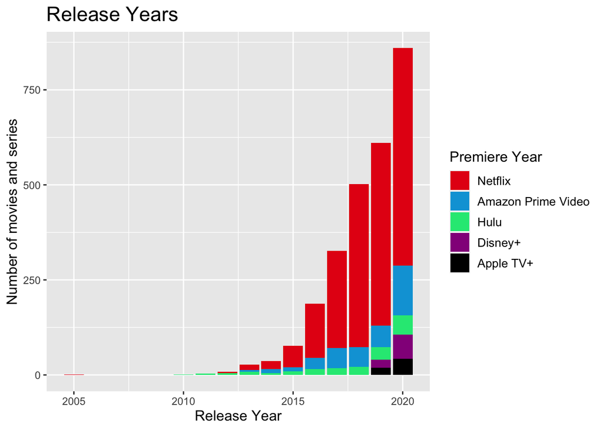

```r
# Adding a column to sort by, will be used as a categorical variable later on
prem_year <- filter(mutate(original_content, Premiere_Year = lubridate::year(Premiere)), Premiere_Year <= 2020, !is.na(Premiere_Year))

ggplot(data = prem_year, mapping = aes(x = Premiere_Year, fill = as.factor(Service))) +
  geom_bar() +
  theme(title = element_text(size = 14), axis.title = element_text(size = 12), legend.title = element_text(size = 12), legend.text = element_text(size = 10)) +
  labs(fill = "Premiere Year", title = "Release Years", x = "Release Year", y = "Number of movies and series") +
  scale_fill_manual(values = original_colors)
```

We can see from the development of releases throughout the years that besides Netflix’s production in 2005, the original content started its rise in 2010, and the production rate increased exponentially for the first 7-8 years. From there on, content production still experienced a linear increase.

## Linear regression model for the amount of original content

We were also interested in finding out whether we could predict the number of productions based on the year even though the year logically can not be the cause of the number of productions. We are also aware that the amount of observations is way too low to create a good regression model, but we wanted to include this nevertheless.

```r
options(scipen = 999)
years <- c(2005:2020)

productions <- function(years, dataframe) {
  productions <- c()
  for (year in years) {
    productions <- c(productions, nrow(filter(select(dataframe, Premiere_Year), Premiere_Year == year)))
  }
  return(productions)
}

linear_regression <- lm(productions(years, prem_year) ~ years, data = filter(prem_year, is.na(match(Premiere_Year, years))))
```

Looking at the summary of this linear regression, we can see that the model explains about 66 percent of the varying values, but the degrees of freedom are very low, at 14. The standard error on this model is also way too high to make any predictions, even if the x variable was responsible for changing production numbers.

```r
summary(linear_regression)
```

```
##
## Call:
## lm(formula = productions(years, prem_year) ~ years, data = filter(prem_year,
##     is.na(match(Premiere_Year, years))))
##
## Residuals:
##     Min      1Q  Median      3Q     Max
## -202.26 -135.10  -24.85   97.79  352.23
##
## Coefficients:
##               Estimate Std. Error t value Pr(>|t|)
## (Intercept) -91812.169  17677.962  -5.194 0.000136 ***
## years           45.703      8.784   5.203 0.000134 ***
## ---
## Signif. codes:  0 '***' 0.001 '**' 0.01 '*' 0.05 '.' 0.1 ' ' 1
##
## Residual standard error: 162 on 14 degrees of freedom
## Multiple R-squared:  0.6591, Adjusted R-squared:  0.6348
## F-statistic: 27.07 on 1 and 14 DF,  p-value: 0.0001339
```

### Change in Netflix content origin over the years

For Netflix, we can see that the ratio between distribution and original content has risen to almost 75% for 2020, which tells us that Netflix tries to avoid the licensing costs of content that they did not produce themselves.

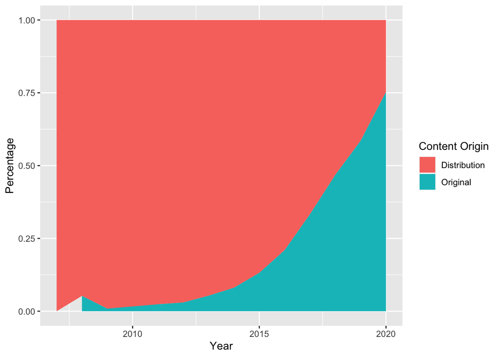

```r
origin_change_area(origin_change(2007, "Netflix"))
```

### Change in Amazon Prime Video content origin over the years

For Amazon Prime Video, we can see that the ratio between distribution and original content has risen to almost 37.5% for the year 2020. From that, we can deduct that Amazon does not produce as much original content as Netflix or Apple TV+ (which will be shown later), but there is a steady rise from 2018 onwards, so there is a chance that Amazon Prime Video is going to follow a similar path.

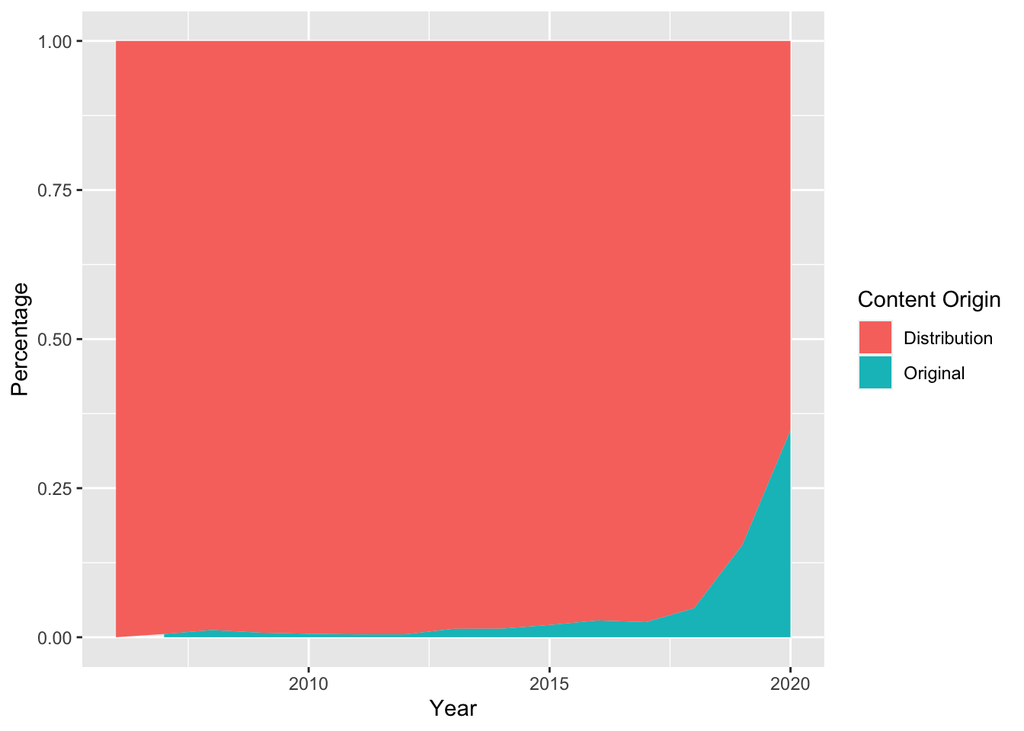

```r
origin_change_area(origin_change(2006, "Prime Video"))
```

### Change in Hulu content origin over the years

Like Amazon Prime, Hulu was very late to start with the mass production of original content as it is sitting at around 25% for 2020.

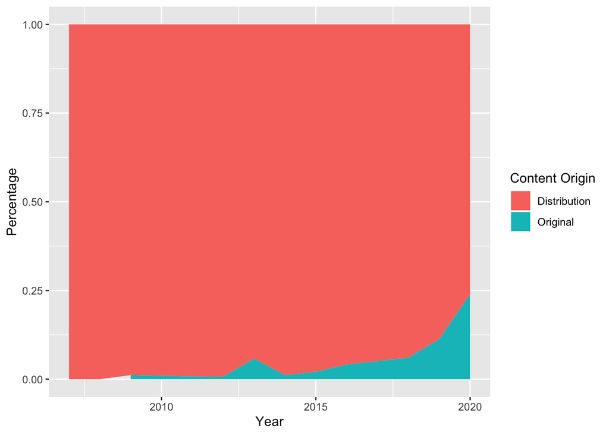

```r
origin_change_area(origin_change(2007, "Hulu"))
```

### Change in Disney+ content origin over the years

In contrast to the three streaming services shown beforehand, Disney entered the market for content streaming very recently, in November of 2019. They were very aware that the production of original content is one of the significant changes in the series and movies industry as of now, which is why they released over 25% original content, which they brought up to a little over 60% in 2020 already.

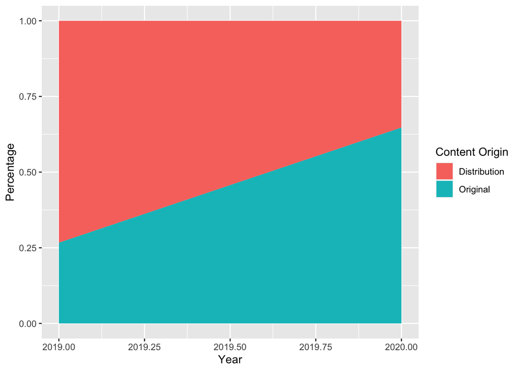

```r
origin_change_area(origin_change(2019, "Disney+"))
```

### Change in Apple TV+ content origin over the years

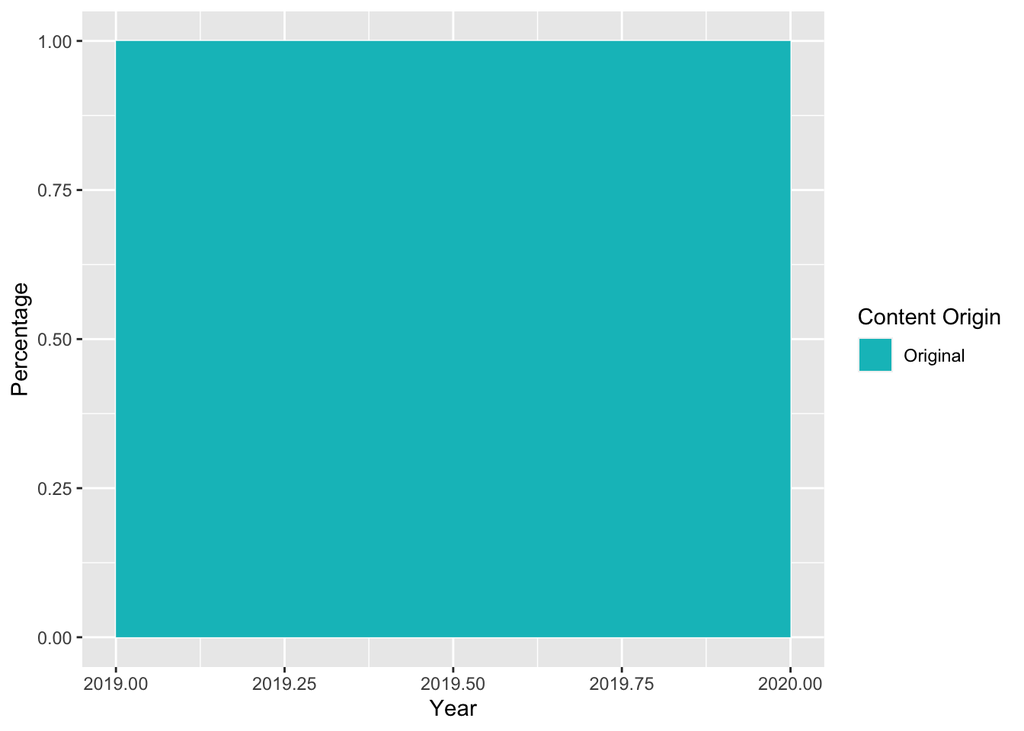

```r
origin_change_area(origin_change(2019, "Apple TV+"), colors = rev(origin_change_area_colors))
```

### Production of original content grouped by months

There is a common agreement in society that most of the exciting movies and series get released during the autumn and winter months, so we made sure to check whether this claim holds up to be true for original content as well.

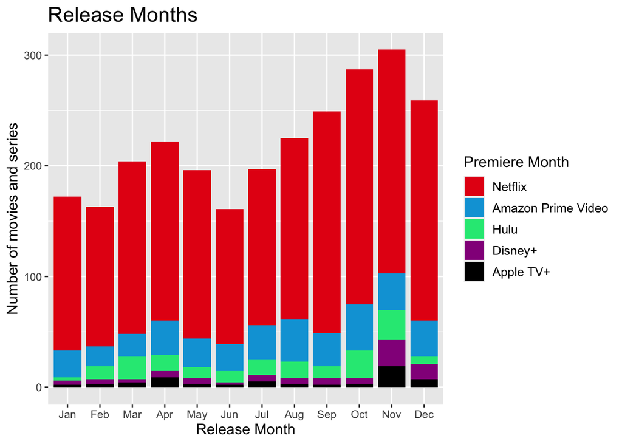

```r
prem_month <- filter(mutate(original_content,
                              Premiere_Month = as.character(lubridate::month(lubridate::ymd(010101) +
                                                                               months(lubridate::month(Premiere) - 1), label = TRUE, abbr = TRUE))),
                              lubridate::year(Premiere) != 2021, !is.na(lubridate::year(Premiere)))

ggplot(data = prem_month, mapping = aes(x = reorder(Premiere_Month, lubridate::month(Premiere)),fill = as.factor(Service))) +
  geom_bar(width = 0.85) +
  theme(title = element_text(size = 14), axis.title = element_text(size = 12), legend.title = element_text(size = 12), legend.text = element_text(size = 10)) +
  labs(fill = "Premiere Month", title = "Release Months", x = "Release Month", y = "Number of movies and series") +
  scale_fill_manual(values = original_colors)
```

We can see that there is indeed a spike for the releases during the autumn period with larger drops right afterward and in the middle of summer. The Disney+ releases artificially increase the November spike since they released with much content in November of 2019.

## Is the original content market flooded by movies or series?

From our feeling, the amount of series compared to movies has also increased steadily, so we figured out that it is interesting to take a look at how the ratio evolved throughout the years for the various streaming services.

```r
series_and_movies <- as_tibble(filter(prem_year %>%
  group_by(Service, Premiere_Year = strtoi(Premiere_Year), Format) %>%
  summarise(Entries = length(Service)), Format == "Film" | Format == "Series"))

percentage_of_series <- function(dataframe) {
  series_percentages <- data.frame(Service = c(), Premiere_Year = c(), Series_Percentage = c())
  years <- c(2000:2020)
  for (service in services) {
    service_rows <- filter(dataframe, Service == service)
    for (year in years) {
      nr_series <- sum(pull(filter(service_rows, Format == "Series", Premiere_Year == year), Entries))
      nr_films <- sum(pull(filter(service_rows, Format == "Film", Premiere_Year == year), Entries))
      series_percentages <- rbind(series_percentages,
                                  data.frame(Service = as.factor(c(service)), Premiere_Year = c(year), Percentage = c(ifelse(nr_series == 0,
                                    ifelse(nr_films == 0, 50, 0), ifelse(nr_films == 0, 100, nr_series / (nr_series + nr_films) * 100)))))
    }
  }
  return(series_percentages)
}
```

We first started by creating two separate graphs that display the number of movies or series grouped by the streaming services, but as you can see, it does not help the situation since there is a general tendency that the streaming services produce more original content either way.

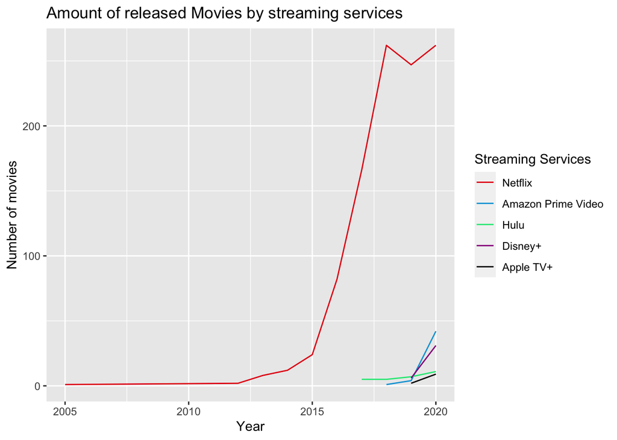

```r
ggplot() +
  geom_line(data = filter(series_and_movies, Format == "Film"), mapping = aes(x = Premiere_Year, y = Entries, colour = as.factor(Service)), label = "Movie") +
  labs(colour = "Streaming Services", title = "Amount of released Movies by streaming services", x = "Year", y = "Number of movies") +
  scale_colour_manual(values = original_colors)
```

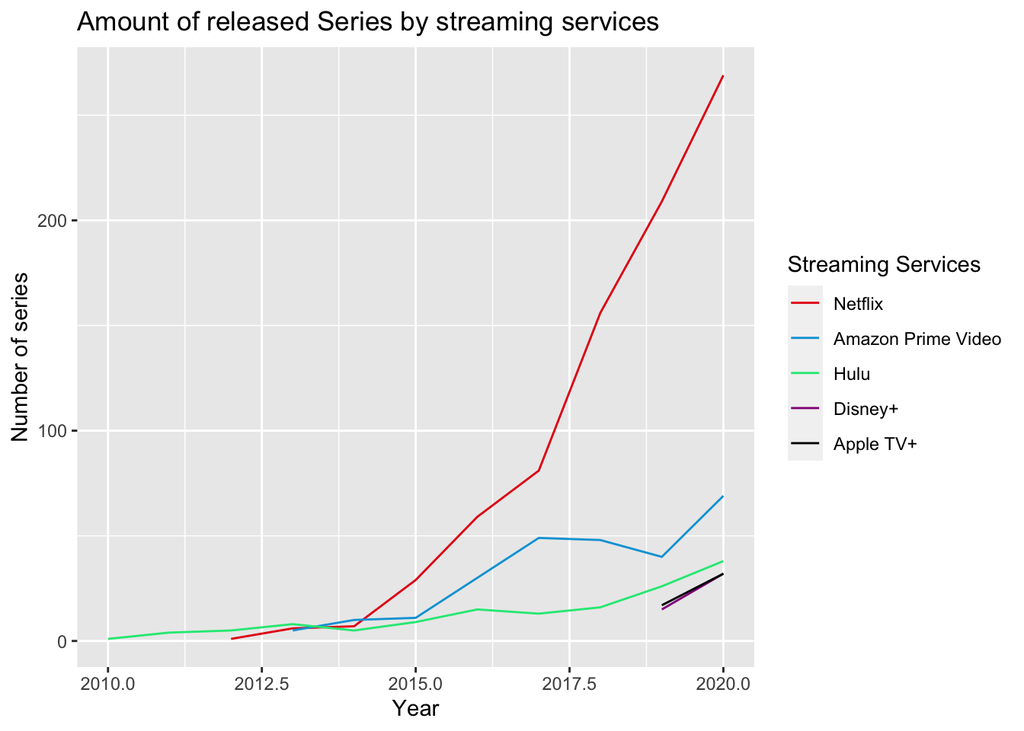

```r
ggplot() +
  geom_line(data = filter(series_and_movies, Format == "Series"), mapping = aes(x = Premiere_Year, y = Entries, colour = as.factor(Service)), label = "Movie") +
  labs(colour = "Streaming Services", title = "Amount of released Series by streaming services", x = "Year", y = "Number of series") +
  scale_colour_manual(values = original_colors)
```

This has lead to the approach that is displayed in the last of the three graphs. We set out that 50% is the baseline for the case that there are no movies and series produced. From there on, we can determine the ratio of series produced to the number of produced movies. For Netflix, for example, it is realistic to say that there is a trend that can be recognized from the data that has been gathered so far.

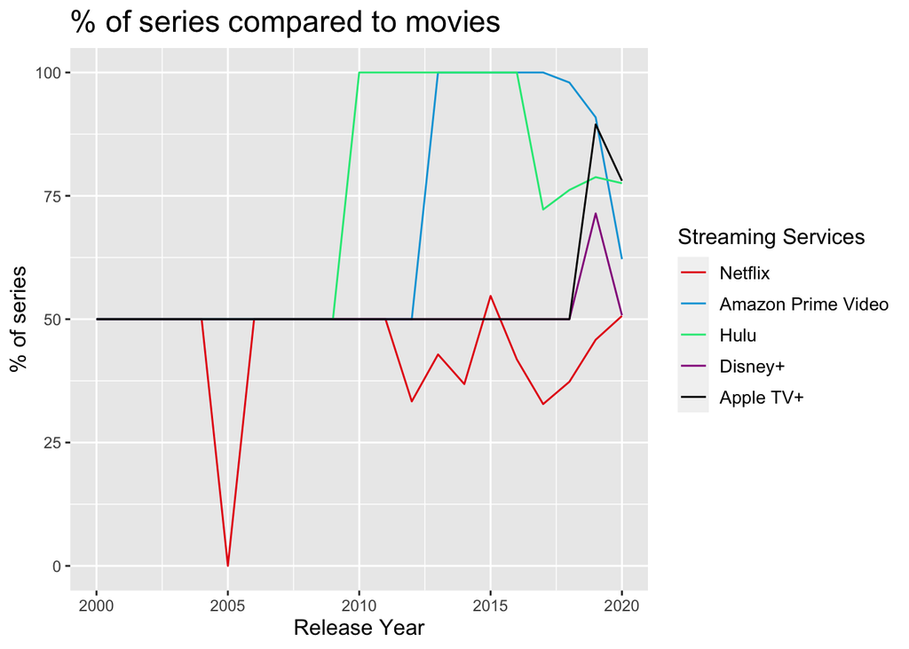

```r
ggplot() +
  geom_line(data = percentage_of_series(series_and_movies), mapping = aes(x = Premiere_Year, y = Percentage, colour = as.factor(Service))) +
  theme(title = element_text(size = 14), axis.title = element_text(size = 12), legend.title = element_text(size = 12), legend.text = element_text(size = 10)) +
  labs(colour = "Streaming Services", title = "% of series compared to movies", x = "Release Year", y = "% of series") +
  scale_color_manual(values = original_colors)
```

## Finding the most produced genres

Finding the most popular genres from our dataset is not easy since the genre column holds multiple values, but tibbles do not support actual multi-value cells. This is why we need to split the strings by their separators. The result is then put into a table with the frequencies. After converting that result into a tibble, the top x genres (20 in our case) can then be filtered and displayed in a bar chart with a flipped axis.

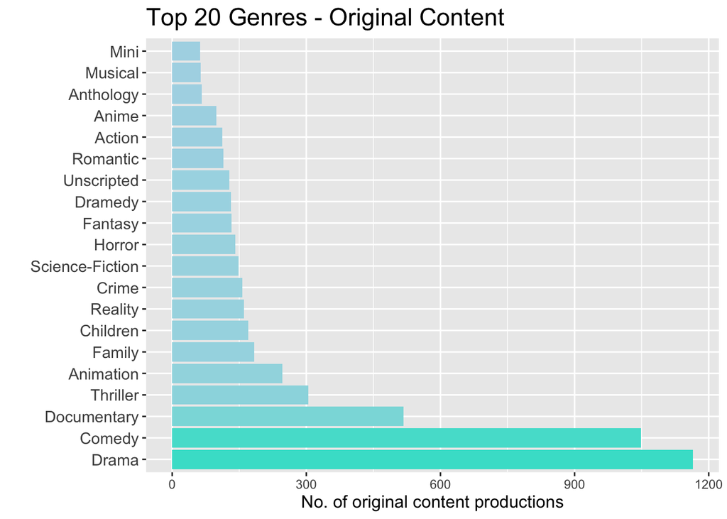

```r
genre_string <- paste(original_content$Genre, collapse = "/")
genre_vector <- strsplit(genre_string, "/")[[1]]
genre_vector_clean <- gsub(" ", "", genre_vector)

genre_frame = transmute(data.frame(table(genre_vector_clean)),
          Genre = genre_vector_clean,
          Count = Freq)

top_x_genres <- function(dataframe, x) {
  arranged_df <- data.frame(Genre = arrange(dataframe, desc(Count))$Genre, Entries = arrange(dataframe, desc(Count))$Count)
  top_x <- data.frame(Genre = c(), Entries = c())
  for (i in 1:x) {
    top_x <- rbind(top_x, arranged_df[i, ])
  }
  return(top_x)
}

genre_count <- as.tibble(top_x_genres(genre_frame, 20) %>% summarise(Genre, Entries = strtoi(Entries)))

ggplot(data = genre_count) +
  geom_bar(mapping = aes(x = reorder(Genre, desc(Entries)), y = Entries, fill = Entries), stat = "identity", show.legend = FALSE) +
  theme(title = element_text(size = 14), axis.title.x = element_text(size = 12), axis.text.y = element_text(size = 11)) +
  labs(title = "Top 20 Genres - Original Content", x = "", y = "No. of original content productions") +
  coord_flip() +
  scale_fill_gradient(low="lightblue", high="turquoise")
```

## Age Ratings

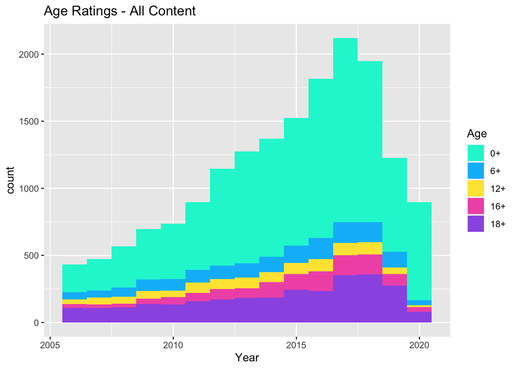

```r
content %>%
  filter(between(Year, 2006, 2020)) %>%
  ggplot() +
    geom_histogram(mapping = aes(x = Year, fill = factor(Age)), binwidth = 1) +
    labs(title = "Age Ratings - All Content", x = "Year", fill = "Age") +
    scale_fill_manual(values = age_histogram_colors)
```

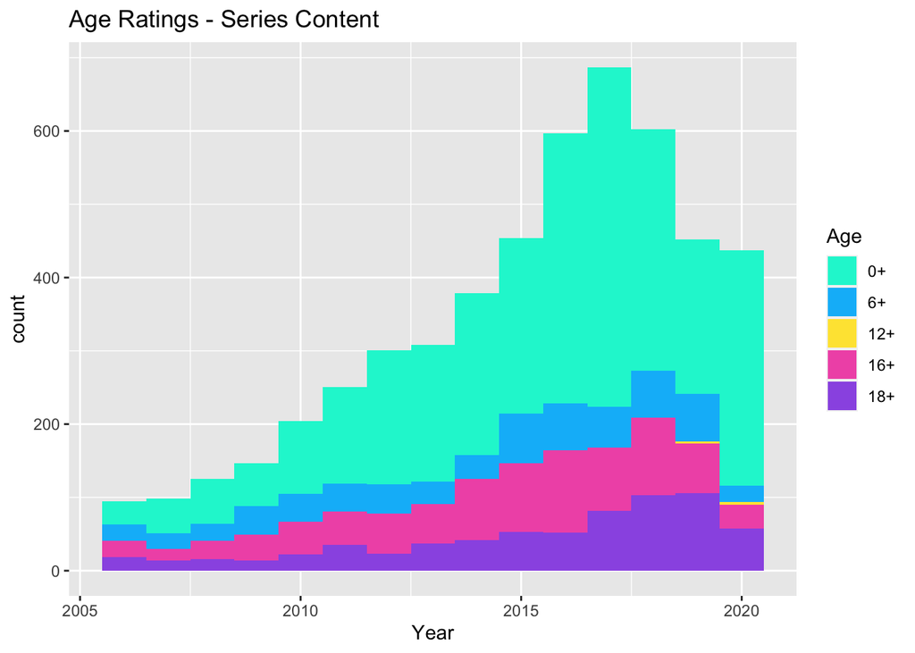

```r
age_histogram("Series")
```

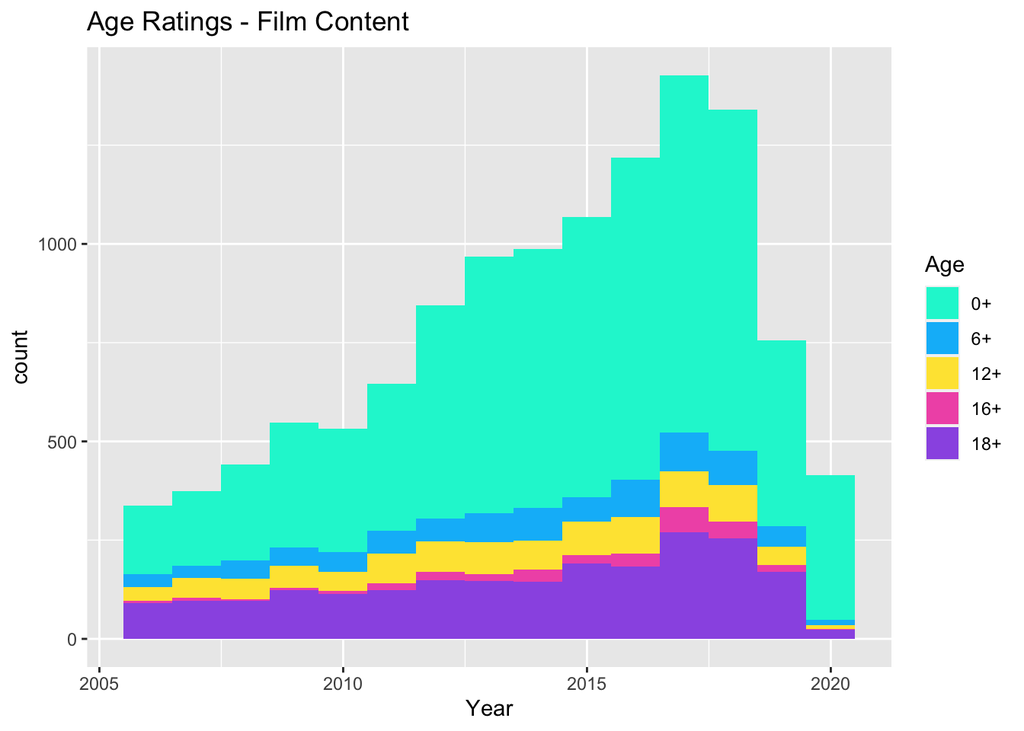

```r
age_histogram("Film")
```

### Age rating for Netflix original content

Netflix does not seem to follow any particular trend on its own. They rather follow the norm.

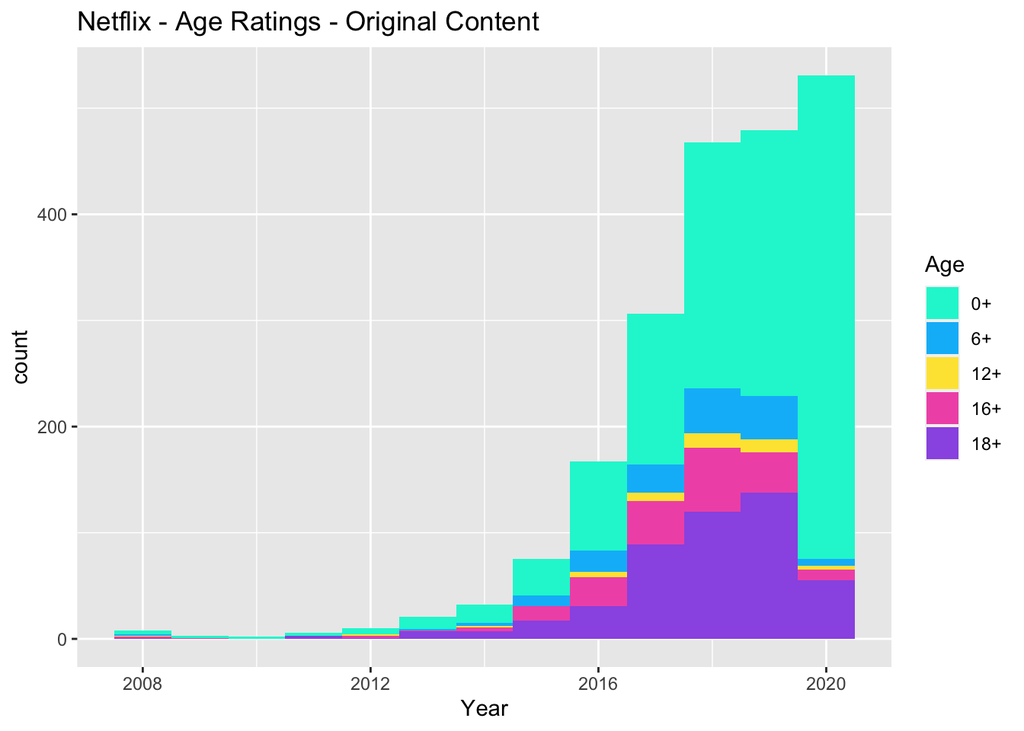

```r
age_histogram_original(2007, "Netflix")
```

### Age rating for all original Amazon Prime Video content

Besides an unusually large amount of 0+ productions, Amazon Prime Video also seems to follow the norm with variations every year, but that can be expected. From this we can derive that the age restrictions on the original content are rather bound to the image the company or streaming service had beforehand or wants to strive towards.

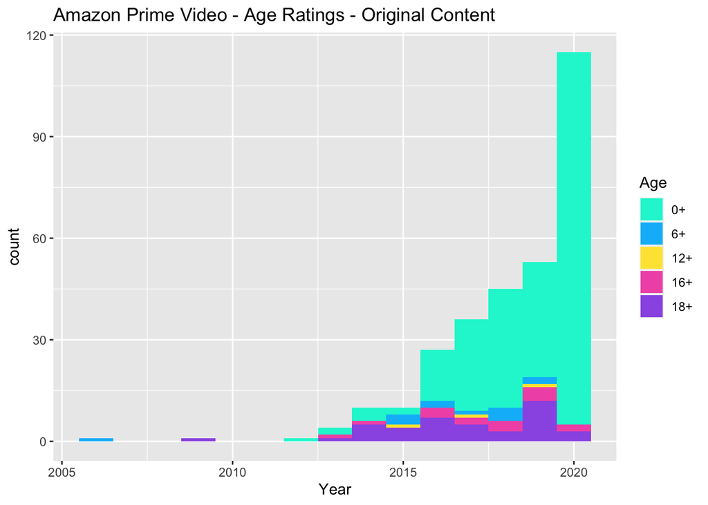

```r
age_histogram_original(2006, "Amazon Prime Video")
```

### Age rating for all original Hulu content

For Hulu, we can see 18+ productions rates that are very high in relation to how large the percentile of 18+ productions of the other streaming services is. Especially for 2019, the percentage of 18+ productions is sitting at almost 50 percent.

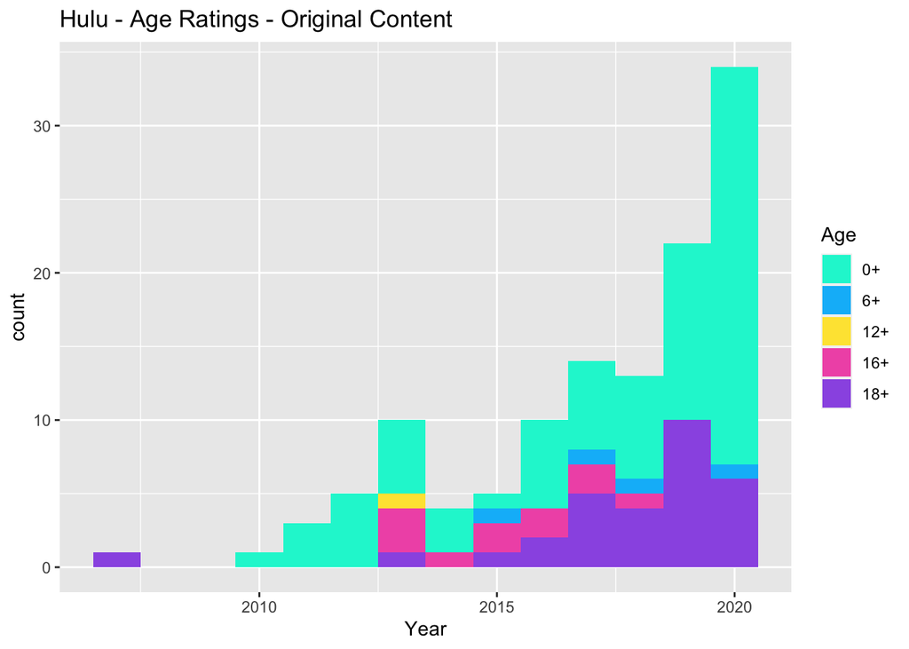

```r
age_histogram_original(2007, "Hulu")
```

### Age rating for all original Disney+ content

In contrast to the streaming services that could be seen beforehand, Disney+ focuses on producing child-oriented content. Even in relation to Apple TV+ (next plot), they are not even “dipping their toes” into the teenage content.

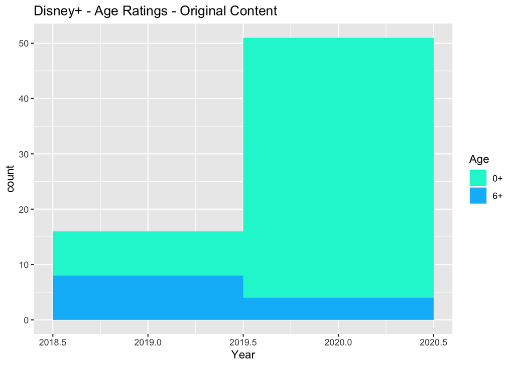

```r
age_histogram_original(2019, "Disney+")
```

### Age rating for all original Apple TV+ content

Apple TV+, just like Disney+, is focused on being able to publish their content for as many people as possible and tries to avoid any age restrictions in the upper end of the scale.

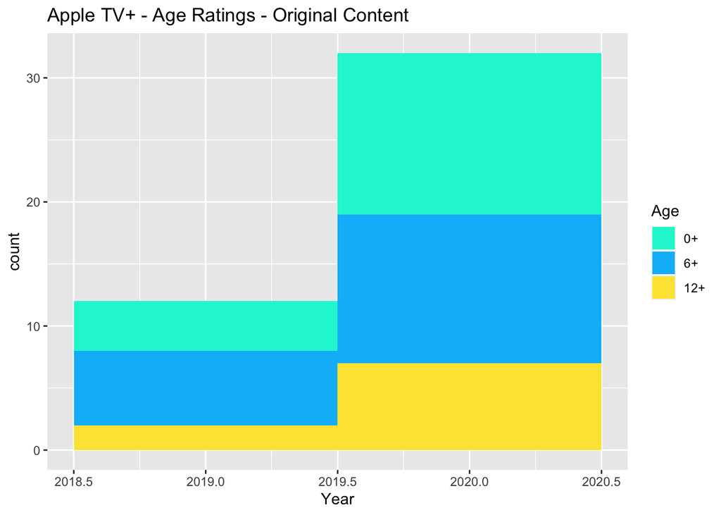

```r
age_histogram_original(2019, "Apple TV+")
```

### Actual regression model

To include a regression model that is accurate in its values, we originally wanted to create a model that analyses the invested resources put into the original content and observe the outcome and compare that model with one that only observes content produced by any streaming service. Sadly, there is not enough precise data that we could find or access, but we wanted to include a more precise one either way.

Since IMDb and Rotten Tomatoes rate movies and series individually, we wanted to observe whether we can find rather strong or weak correlations. We multiplied the IMDb score by ten to map it to the Rotten Tomatoes percentage for this model.

While we can see that the r-squared value is relatively low in comparison to the previous regression model, it is still high enough for our purpose. The residual standard error only lies at around 8.5 percent points, which is pretty accurate for what we are observing.

```r
regression <- lm((content$IMDb * 10) ~ content$`Rotten Tomatoes`)
summary(regression)
```

```
##
## Call:
## lm(formula = (content$IMDb * 10) ~ content$`Rotten Tomatoes`)
##
## Residuals:
##     Min      1Q  Median      3Q     Max
## -54.287  -5.170   0.623   5.578  28.326
##
## Coefficients:
##                           Estimate Std. Error t value            Pr(>|t|)
## (Intercept)               48.58377    0.30152  161.13 <0.0000000000000002 ***
## content$`Rotten Tomatoes`  0.25226    0.00417   60.49 <0.0000000000000002 ***
## ---
## Signif. codes:  0 '***' 0.001 '**' 0.01 '*' 0.05 '.' 0.1 ' ' 1
##
## Residual standard error: 8.544 on 6155 degrees of freedom
##   (18241 observations deleted due to missingness)
## Multiple R-squared:  0.3729, Adjusted R-squared:  0.3728
## F-statistic:  3659 on 1 and 6155 DF,  p-value: < 0.00000000000000022
```

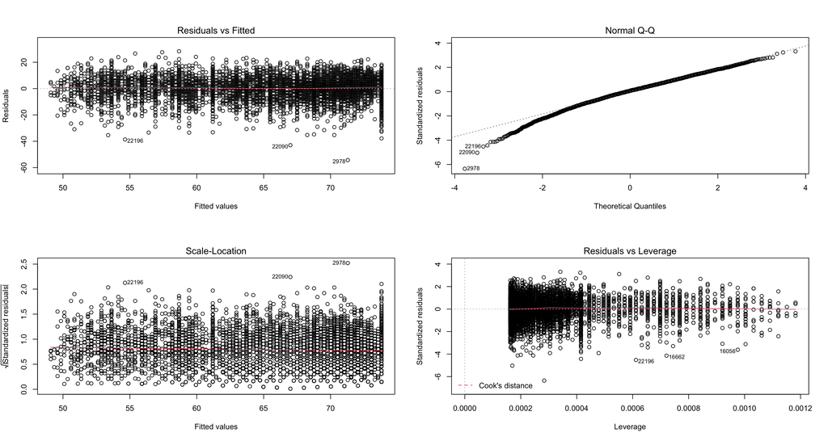

```r
par(mfrow = c(2,2))
plot(regression)
```

### Exporting the data frame to CSV

To make it reusable for other people, we also wanted to export our final data frame for the following usage. After some further tweaks, we are also planning to publish this dataset to Kaggle.

```r
write.csv(original_content, "../original_content.csv", row.names = TRUE)
```